# Lameness Data Analysis Report

System Wide Comparision

Author

Gerard Cramer Dairy Cow Foot Doc PLLC

Published

February 18, 2025

[figure not shown]

# Introduction

This is a summary of the hoof trimming and lesions data from Dec 2022 to Nov 2024. Historical data was used starting from 2018 was used to determine the lesion history of cows trimmed in the last year.

Of note in this report you will at times see the data split out into the following categories:

- *All Cases:*
  - Includes all occurrences of a lesion.
  - A cow could have had the lesion once or 5 times in the past year and all them are included.
  - This category is important as it shows how many lame cows the go through the chute.
- *First Cases:*
  - Includes only cows that had a lesion for the first time in the past year.
  - I consider this category the most important category as it tells us how many lame cows we are creating.
  - The difference between *first cases* and *all cases* paints a picture of the number of chronic cows.
- *Second Cases:*
  - Includes only cows that had a lesion for the second time in the past year.
  - This category includes cows that will eventually become chronic cows but also some cows that might just have needed a bit more time to heel.
  - Three or more cases:
    - Includes cows that had a lesion three or more times in the past year.
    - These are the chronic cows and once we need to manage appropriately.
- *Graphs and Tables:*
  - Tables and figures will be broken down by lactation group, months, or across DIM categories.
  - Most figures are survival curves and have % of cows still alive on the *y-axis* and time since the lesion on the *x-axis.* These graphs have different curves to show the difference between cows.
    - In these survival curves, a line closer to the top indicates that cows do better.
    - The shading around lines indicates the precision around the estimate of the line. Typically, if the shading overlaps, we consider the lines similar with no evidence of a difference.

# Lesions Incidence by Lactation

**Lact 1**

Figure 1: Comparision of Lesions between Lactation Groups

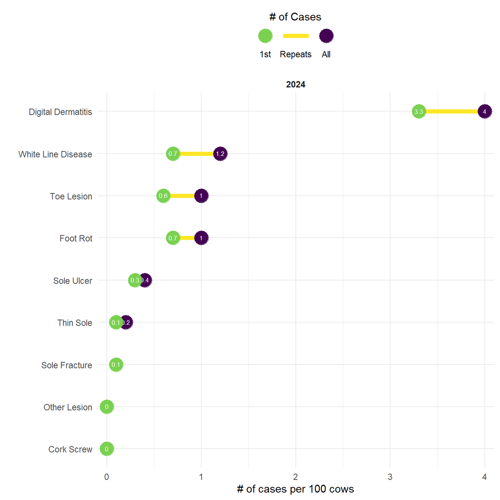

**Lact 2**

Figure 2: Comparision of Lesions between Lactation Groups

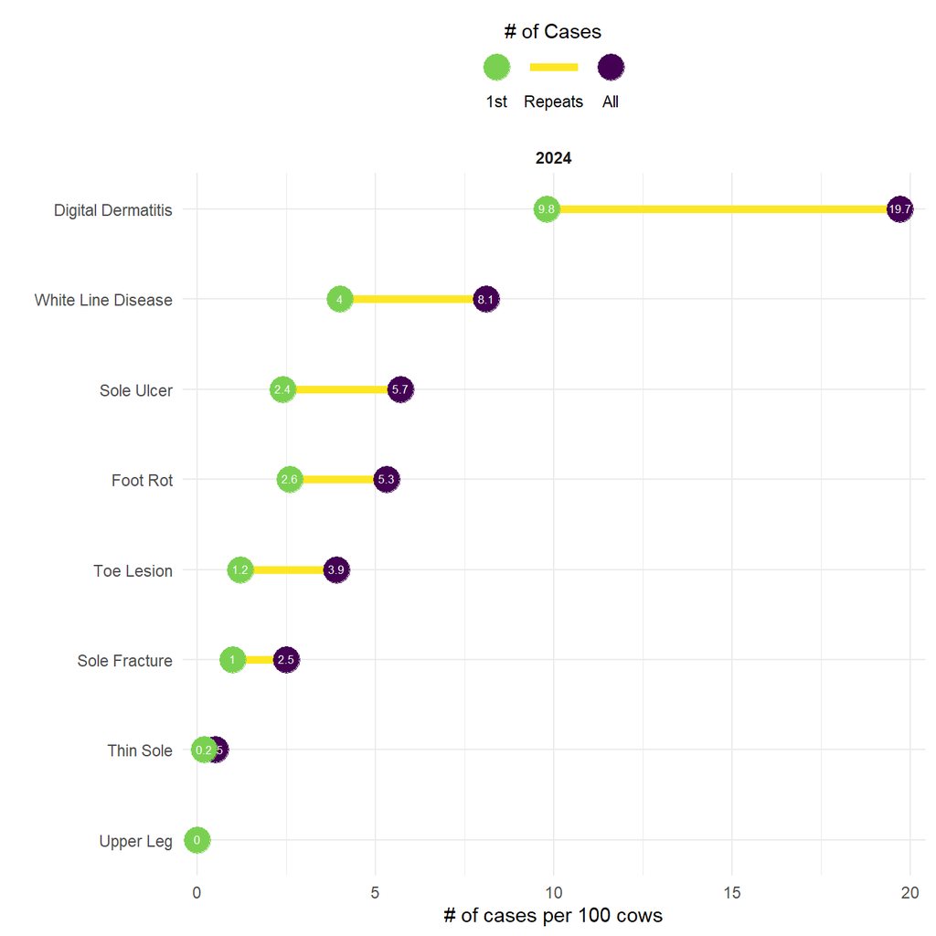

**Lact 3**

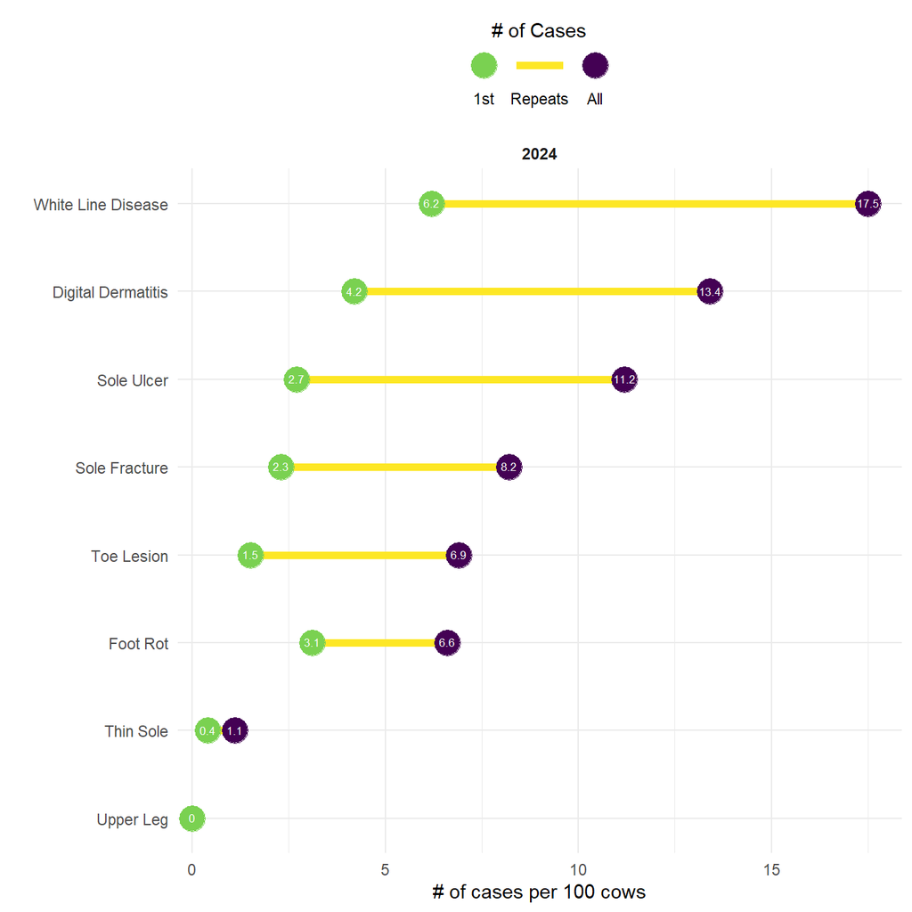

Figure 3

**Lact 4**

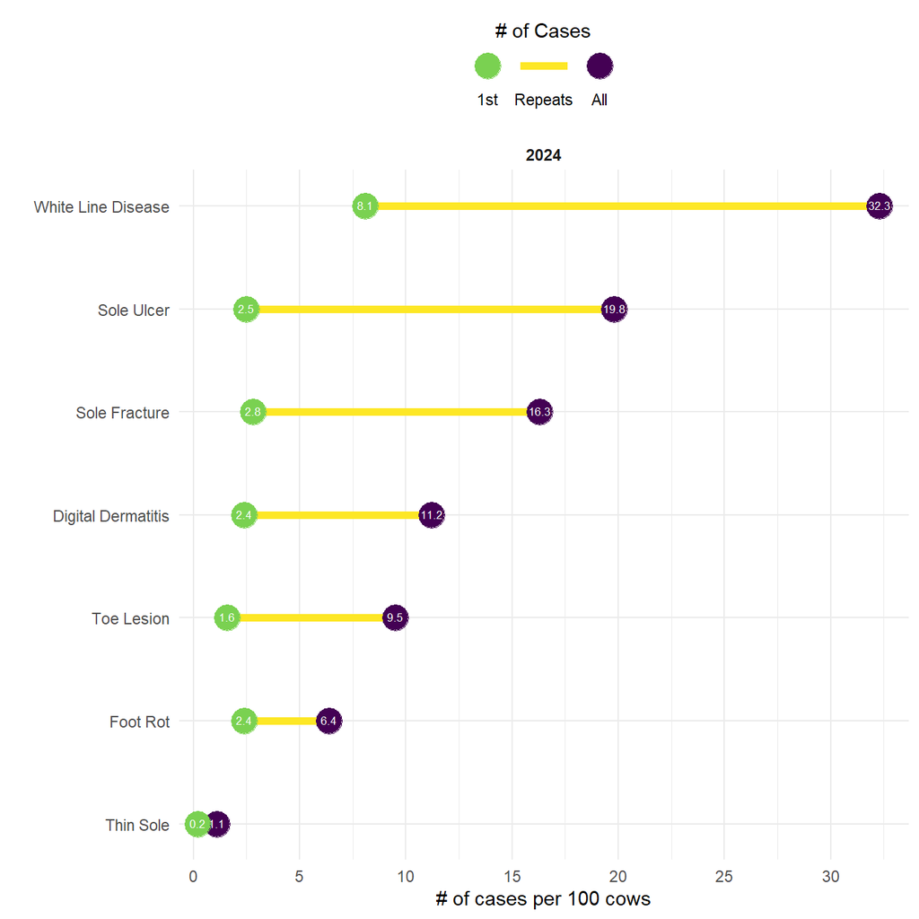

Figure 4

**Lact 5 Plus**

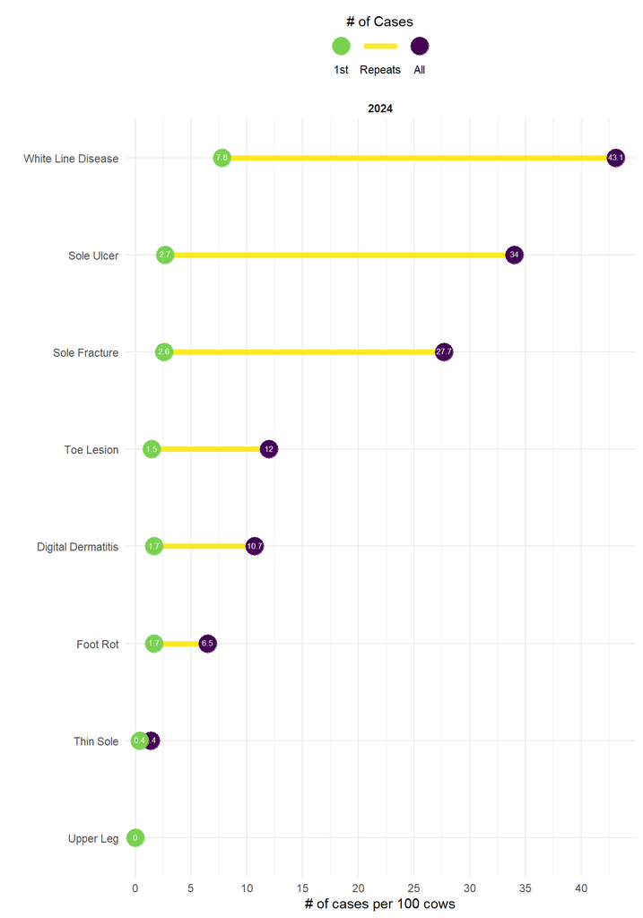

Figure 5